# Weight Lifting Exercise

Khoa Tran

11/08/2020

# Overview

Using devices such as Jawbone Up, Nike FuelBand, and Fitbit it is now possible to collect a large amount of data about personal activity relatively inexpensively. These type of devices are part of the quantified self movement – a group of enthusiasts who take measurements about themselves regularly to improve their health, to find patterns in their behavior, or because they are tech geeks. One thing that people regularly do is quantify how much of a particular activity they do, but they rarely quantify how well they do it. In this project, your goal will be to use data from accelerometers on the belt, forearm, arm, and dumbell of 6 participants. They were asked to perform barbell lifts correctly and incorrectly in 5 different ways. More information is available from the website here: http://web.archive.org/web/20161224072740/http:/groupware.les.inf.puc-rio.br/har (see the section on the Weight Lifting Exercise Dataset).

# Preprocessing

Load the needed library

```r
library(dplyr)
library(caret)
library(cowplot)
library(randomForest)
library(ggplot2)
```

More information can about the dataset can be found at “http://groupware.les.inf.puc-rio.br/har”

Download the 2 csv file, save them in a new directory call Data, and load the dataset into R

```r
# check if the file is downloaded, and create the needed directory
if(!file.exists("Data")){dir.create("Data")}
fileName <- "pml-training.csv"
path <- getwd()
if(!file.exists(paste(path,"/Data","/",fileName,sep = ""))){
        url <- "https://d396qusza40orc.cloudfront.net/predmachlearn/pml-training.csv"
        download.file(url,destfile = paste(path,"/Data","/",fileName,sep = "")) }


fileName <- "pml-testing.csv"
path <- getwd()
if(!file.exists(paste(path,"/Data","/",fileName,sep = ""))){
        url <- "https://d396qusza40orc.cloudfront.net/predmachlearn/pml-testing.csv"
        download.file(url,destfile = paste(path,"/Data","/",fileName,sep = "")) }

# Load the 2 file into r
train <- read.csv("./Data/pml-training.csv")[,-1]
test <- read.csv("./Data/pml-testing.csv")[-1]

str(train)
```

```
## 'data.frame':    19622 obs. of  159 variables:
##  $ user_name               : chr  "carlitos" "carlitos" "carlitos" "carlitos" ...
##  $ raw_timestamp_part_1    : int  1323084231 1323084231 1323084231 1323084232 1323084232 1323084232 1323084232 1323084232 1323084232 1323084232 ...
##  $ raw_timestamp_part_2    : int  788290 808298 820366 120339 196328 304277 368296 440390 484323 484434 ...
##  $ cvtd_timestamp          : chr  "05/12/2011 11:23" "05/12/2011 11:23" "05/12/2011 11:23" "05/12/2011 11:23" ...
##  $ new_window              : chr  "no" "no" "no" "no" ...
##  $ num_window              : int  11 11 11 12 12 12 12 12 12 12 ...
##  $ roll_belt               : num  1.41 1.41 1.42 1.48 1.48 1.45 1.42 1.42 1.43 1.45 ...
##  $ pitch_belt              : num  8.07 8.07 8.07 8.05 8.07 8.06 8.09 8.13 8.16 8.17 ...
##  $ yaw_belt                : num  -94.4 -94.4 -94.4 -94.4 -94.4 -94.4 -94.4 -94.4 -94.4 -94.4 ...
##  $ total_accel_belt        : int  3 3 3 3 3 3 3 3 3 3 ...
##  $ kurtosis_roll_belt      : chr  "" "" "" "" ...
##  $ kurtosis_picth_belt     : chr  "" "" "" "" ...
##  $ kurtosis_yaw_belt       : chr  "" "" "" "" ...
##  $ skewness_roll_belt      : chr  "" "" "" "" ...
```

[output cut: 86 more lines]

```r
dim(train)
```

```
## [1] 19622   159
```

At first glance into the structure of the dataset, we can see that there are lots of column with NAs values, and empty string. We should remove them before using any model

Lets deal NAs columns first. We can count the number of times NA appear in the each column then divide them by the length of the trainset (Since the model will be train base on the trainset). If the percentage excess a certain threshold ( 0.97 in this case ), we can remove them

```r
naPercent <- apply(is.na(train),2,sum)/ 19622

naPercent
```

```
##                user_name     raw_timestamp_part_1     raw_timestamp_part_2
##                0.0000000                0.0000000                0.0000000
##           cvtd_timestamp               new_window               num_window
##                0.0000000                0.0000000                0.0000000
##                roll_belt               pitch_belt                 yaw_belt
##                0.0000000                0.0000000                0.0000000
##         total_accel_belt       kurtosis_roll_belt      kurtosis_picth_belt
##                0.0000000                0.0000000                0.0000000
##        kurtosis_yaw_belt       skewness_roll_belt     skewness_roll_belt.1
##                0.0000000                0.0000000                0.0000000
##        skewness_yaw_belt            max_roll_belt           max_picth_belt
##                0.0000000                0.9793089                0.9793089
##             max_yaw_belt            min_roll_belt           min_pitch_belt
##                0.0000000                0.9793089                0.9793089
##             min_yaw_belt      amplitude_roll_belt     amplitude_pitch_belt
##                0.0000000                0.9793089                0.9793089
##       amplitude_yaw_belt     var_total_accel_belt            avg_roll_belt
##                0.0000000                0.9793089                0.9793089
##         stddev_roll_belt            var_roll_belt           avg_pitch_belt
##                0.9793089                0.9793089                0.9793089
##        stddev_pitch_belt           var_pitch_belt             avg_yaw_belt
##                0.9793089                0.9793089                0.9793089
##          stddev_yaw_belt             var_yaw_belt             gyros_belt_x
##                0.9793089                0.9793089                0.0000000
##             gyros_belt_y             gyros_belt_z             accel_belt_x
##                0.0000000                0.0000000                0.0000000
##             accel_belt_y             accel_belt_z            magnet_belt_x
##                0.0000000                0.0000000                0.0000000
##            magnet_belt_y            magnet_belt_z                 roll_arm
##                0.0000000                0.0000000                0.0000000
##                pitch_arm                  yaw_arm          total_accel_arm
##                0.0000000                0.0000000                0.0000000
##            var_accel_arm             avg_roll_arm          stddev_roll_arm
##                0.9793089                0.9793089                0.9793089
##             var_roll_arm            avg_pitch_arm         stddev_pitch_arm
##                0.9793089                0.9793089                0.9793089
##            var_pitch_arm              avg_yaw_arm           stddev_yaw_arm
##                0.9793089                0.9793089                0.9793089
##              var_yaw_arm              gyros_arm_x              gyros_arm_y
##                0.9793089                0.0000000                0.0000000
```

[output cut: 51 more lines]

```
##                0.9793089                0.9793089                0.0000000
##      total_accel_forearm        var_accel_forearm         avg_roll_forearm
##                0.0000000                0.9793089                0.9793089
##      stddev_roll_forearm         var_roll_forearm        avg_pitch_forearm
##                0.9793089                0.9793089                0.9793089
##     stddev_pitch_forearm        var_pitch_forearm          avg_yaw_forearm
##                0.9793089                0.9793089                0.9793089
##       stddev_yaw_forearm          var_yaw_forearm          gyros_forearm_x
##                0.9793089                0.9793089                0.0000000
##          gyros_forearm_y          gyros_forearm_z          accel_forearm_x
##                0.0000000                0.0000000                0.0000000
##          accel_forearm_y          accel_forearm_z         magnet_forearm_x
##                0.0000000                0.0000000                0.0000000
##         magnet_forearm_y         magnet_forearm_z                   classe
##                0.0000000                0.0000000                0.0000000
```

```r
removeFeature <- names(naPercent [naPercent >0.97])
#  the feautures will be removed
removeFeature
```

```
##  [1] "max_roll_belt"            "max_picth_belt"
##  [3] "min_roll_belt"            "min_pitch_belt"
##  [5] "amplitude_roll_belt"      "amplitude_pitch_belt"
##  [7] "var_total_accel_belt"     "avg_roll_belt"
##  [9] "stddev_roll_belt"         "var_roll_belt"
## [11] "avg_pitch_belt"           "stddev_pitch_belt"
## [13] "var_pitch_belt"           "avg_yaw_belt"
## [15] "stddev_yaw_belt"          "var_yaw_belt"
## [17] "var_accel_arm"            "avg_roll_arm"
## [19] "stddev_roll_arm"          "var_roll_arm"
## [21] "avg_pitch_arm"            "stddev_pitch_arm"
## [23] "var_pitch_arm"            "avg_yaw_arm"
## [25] "stddev_yaw_arm"           "var_yaw_arm"
## [27] "max_roll_arm"             "max_picth_arm"
## [29] "max_yaw_arm"              "min_roll_arm"
```

[output cut: 19 more lines]

```r
trainset <- select(train, -removeFeature )
testset <- select(test,-removeFeature )
```

In addition ,we can remove the near zero variance since they provide less predictive power. Doing this also help us remove the almost all empty string columns

```r
removeFeatureNZR <- nearZeroVar(trainset)
trainset <- trainset[,-removeFeatureNZR]
testset <- testset[,-removeFeatureNZR]
```

We convert the label into factor

```r
trainset$classe <- as.factor(trainset$classe)
```

Now we can manually look into the dataset to remove the predictor that we think that it do not needed

cvtd_timestamp,user_name is the two I believe our model will has a difficult time handling

```r
trainset <- select(trainset,-c("cvtd_timestamp","user_name"))
testset <- select(testset,-c("cvtd_timestamp","user_name"))

# This is how our final trainset look like
str(trainset)
```

```
## 'data.frame':    19622 obs. of  56 variables:
##  $ raw_timestamp_part_1: int  1323084231 1323084231 1323084231 1323084232 1323084232 1323084232 1323084232 1323084232 1323084232 1323084232 ...
##  $ raw_timestamp_part_2: int  788290 808298 820366 120339 196328 304277 368296 440390 484323 484434 ...
##  $ num_window          : int  11 11 11 12 12 12 12 12 12 12 ...
##  $ roll_belt           : num  1.41 1.41 1.42 1.48 1.48 1.45 1.42 1.42 1.43 1.45 ...
##  $ pitch_belt          : num  8.07 8.07 8.07 8.05 8.07 8.06 8.09 8.13 8.16 8.17 ...
##  $ yaw_belt            : num  -94.4 -94.4 -94.4 -94.4 -94.4 -94.4 -94.4 -94.4 -94.4 -94.4 ...
##  $ total_accel_belt    : int  3 3 3 3 3 3 3 3 3 3 ...
##  $ gyros_belt_x        : num  0 0.02 0 0.02 0.02 0.02 0.02 0.02 0.02 0.03 ...
##  $ gyros_belt_y        : num  0 0 0 0 0.02 0 0 0 0 0 ...
##  $ gyros_belt_z        : num  -0.02 -0.02 -0.02 -0.03 -0.02 -0.02 -0.02 -0.02 -0.02 0 ...
##  $ accel_belt_x        : int  -21 -22 -20 -22 -21 -21 -22 -22 -20 -21 ...
##  $ accel_belt_y        : int  4 4 5 3 2 4 3 4 2 4 ...
##  $ accel_belt_z        : int  22 22 23 21 24 21 21 21 24 22 ...
##  $ magnet_belt_x       : int  -3 -7 -2 -6 -6 0 -4 -2 1 -3 ...
```

[output cut: 42 more lines]

```r
dim(trainset)
```

```
## [1] 19622    56
```

Split the data into 2 set 1 for training, 1 for validation

```r
inTrain  <- createDataPartition(trainset$classe, p=0.7, list=FALSE)
valiSet <- trainset[-inTrain, ]
trainset  <- trainset[inTrain, ]
```

# Model building

We going to use Random Forest for this dataset.

RandomForest dose’t need cross validation, when we train a model,say 100 trees , that each tree use boostrape to sample from original data as train set ,about 1/3 of data not include which is called oob data, and and,since tree have it’s oob data we can use it. Because multiple bagging in process of training random forest prevents over-fitting.

```r
set.seed(123)

rfModel <- randomForest(classe ~. , data = trainset , proximity = TRUE, importance = TRUE)

saveRDS(rfModel, "./Data/rfModel.RDS")
```

[output not shown]

The RF model run with only OOB error rate only 0.15%, with 500 trees and 7 variable slipt

## Optimization

Our OOB rate is very good already, but lets try and find a way to optimize the model

First lets look at the error rate when the number of tree increase to guess if we can reduce the error by increasing the number of tree or not

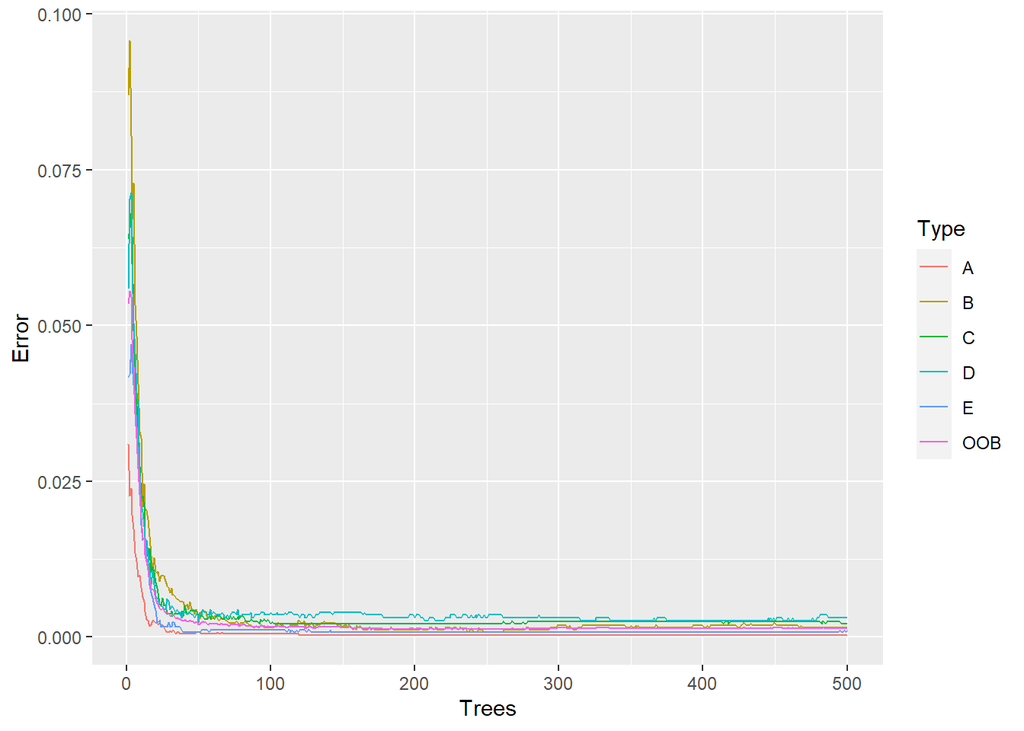

```r
# Re-formating the err.rate to suit ggplot2
nameError <- dimnames(rfModel$err.rate)[[2]]

error.data <- data.frame(
        Trees = rep(1:nrow(rfModel$err.rate) , times = dim(rfModel$err.rate)[2]),
        Type = rep(nameError,each = nrow(rfModel$err.rate)),
        Error = c(rfModel$err.rate[,nameError[1]],
                  rfModel$err.rate[,nameError[2]],
                  rfModel$err.rate[,nameError[3]],
                  rfModel$err.rate[,nameError[4]],
                  rfModel$err.rate[,nameError[5]],
                  rfModel$err.rate[,nameError[6]]
                  )
)


ggplot(data = error.data , aes(x = Trees , Error)) + geom_line(aes(color = Type))
```

Seem like the error has level off already and increase the number of tree in the forest will not help us

Lets try to change the number of variable slipt , we can try from 1 to 15 as the number of slipt

```r
set.seed(123)

for(i in 1:15){
        tempModel <- randomForest(classe ~ . , data = trainset , mytry = i)

        saveRDS(tempModel,paste("./Data/tempModel",i,".RDS", sep = ""))
}

oob.values
```

```r
oob.values <- vector(length = 15)
for(i in 1:15){
        tempModel <- readRDS(paste("./Data/tempModel",i,".RDS", sep = ""))
        oob.values[i] <- tempModel$err.rate[nrow(tempModel$err.rate),1]

}

oob.values
```

```
##  [1] 0.0013831259 0.0013103298 0.0012375337 0.0010919415 0.0009463493
##  [6] 0.0010191454 0.0009463493 0.0015287181 0.0013831259 0.0011647376
## [11] 0.0012375337 0.0013103298 0.0014559220 0.0013831259 0.0010191454
```

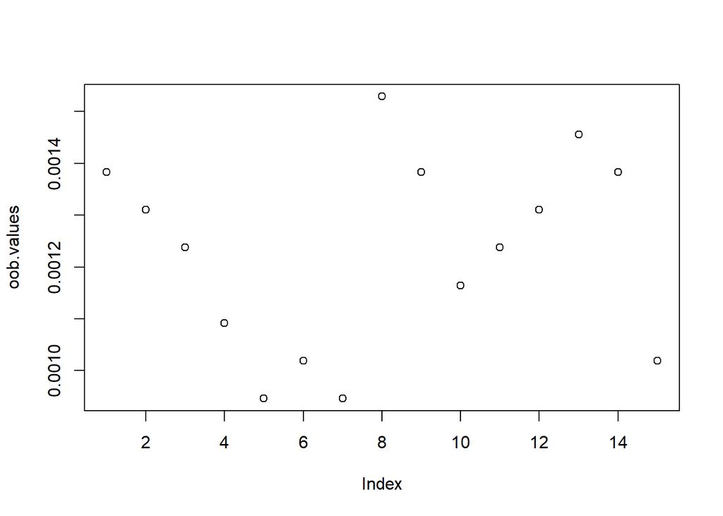

```r
plot(oob.values)
```

As we can see, the default value of 7 has the minimum out-of-bag values, but we can see the different in oob error is very small throughout the different number of slipt. So there no need to re-train the model

Lets apply the model to the valiSet to see how our model deal with unknown data

```r
confusionMatrix(valiSet$classe,predict(rfModel,valiSet))
```

```
## Confusion Matrix and Statistics
##
##           Reference
## Prediction    A    B    C    D    E
##          A 1674    0    0    0    0
##          B    0 1139    0    0    0
##          C    0    1 1025    0    0
##          D    0    0    0  964    0
##          E    0    0    0    0 1082
##
## Overall Statistics
##
##                Accuracy : 0.9998
##                  95% CI : (0.9991, 1)
##     No Information Rate : 0.2845
##     P-Value [Acc > NIR] : < 2.2e-16
##
##                   Kappa : 0.9998
##
##  Mcnemar's Test P-Value : NA
##
## Statistics by Class:
##
##                      Class: A Class: B Class: C Class: D Class: E
## Sensitivity            1.0000   0.9991   1.0000   1.0000   1.0000
## Specificity            1.0000   1.0000   0.9998   1.0000   1.0000
## Pos Pred Value         1.0000   1.0000   0.9990   1.0000   1.0000
## Neg Pred Value         1.0000   0.9998   1.0000   1.0000   1.0000
## Prevalence             0.2845   0.1937   0.1742   0.1638   0.1839
## Detection Rate         0.2845   0.1935   0.1742   0.1638   0.1839
## Detection Prevalence   0.2845   0.1935   0.1743   0.1638   0.1839
## Balanced Accuracy      1.0000   0.9996   0.9999   1.0000   1.0000
```

Now, just look into our model to see how our model determine the important of each feature

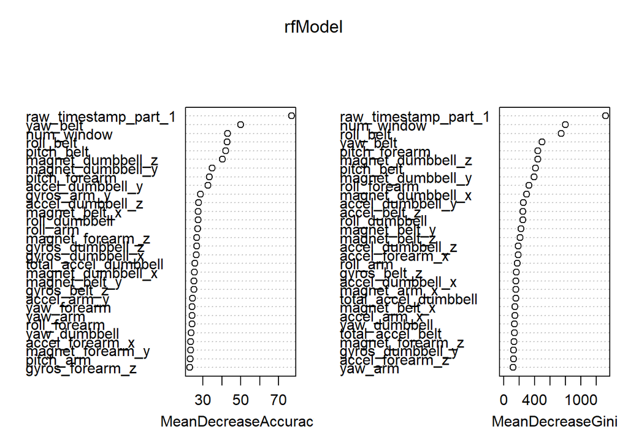

```r
varImpPlot(rfModel)
```

## Prediction

Finally,we can use our model to predict the un-tested data to predict

```r
predict(rfModel,testset)
```

```
##  1  2  3  4  5  6  7  8  9 10 11 12 13 14 15 16 17 18 19 20
##  B  A  B  A  A  E  D  B  A  A  B  C  B  A  E  E  A  B  B  B
## Levels: A B C D E
```